# Project 5

Nur Syazwani Binti Mohammad Fadzli (127032781)

## Introduction

For this project, I decided to focus on media releases from the New Zealand Government’s Beehive website that were connected to Simon Watts and the Climate Change portfolio. I searched for results related to climate and environmental issues because these topics are becoming increasingly important in New Zealand and globally. Climate change affects many aspects of society, including the environment, economy, and future policies, so I was interested in exploring how these issues are communicated to the public through official government media releases. I manually saved several HTML pages from the Beehive website and used them for ethical web scraping and data analysis in R.

I chose this topic because I wanted to analyse real political communication data. Since Simon Watts is responsible for the Climate Change portfolio, I thought it would be interesting to investigate the types of environmental topics that appeared most frequently in his public announcements.

When using data from the Beehive website, it is important to follow ethical data practices. I checked the website’s robots.txt and copyright guidelines to make sure the data could be used appropriately for educational purposes. The website content should not be scraped excessively or misrepresented, and the original source must always be acknowledged. In this project, I used publicly available data from the Beehive website together with information sourced from Wikipedia through its API.

Data sources:

https://www.beehive.govt.nz/ https://en.wikipedia.org/

## Visualisation

The purpose of my visualisation was to explore the main climate-related themes that appeared in Simon Watts’ Beehive media releases. I wanted to investigate the types of environmental topics that were most commonly communicated through official government announcements. Rather than only counting the number of media releases, I focused on analysing the language used in the release titles to better understand the communication priorities connected to climate policy.

To do this, I used text analysis techniques from the stringr package in R. I searched the release titles for keywords related to climate and environmental issues, including terms such as “climate”, “energy”, “emissions”, “sustainability”, “environment”, and “carbon”. I then counted how often these words appeared and visualised the results using ggplot2. The visualisation helps show which climate-related topics appeared most frequently in the public communications associated with the Climate Change portfolio.

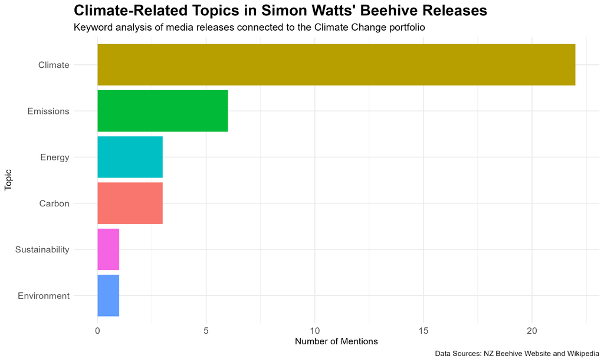

## Creativity

I think the creative part of my project came from the way I used both political data and text analysis to explore climate communication in New Zealand. Instead of only counting the number of Beehive media releases, I wanted to investigate the types of climate-related topics that appeared most frequently in Simon Watts’ public announcements as Minister for Climate Change.

To do this, I combined data from the Beehive website and Wikipedia using a left join in R. I then used functions from the stringr package to search release titles for keywords such as “climate”, “energy”, “emissions”, “environment”, and “carbon”. This allowed me to analyse how environmental issues were discussed through official government media releases.

For the visualisation, I created a horizontal bar chart using ggplot2 to compare how often each climate-related keyword appeared in the dataset. I chose a bar chart because it made it easier to clearly compare the frequency of different topics and made the results more visually understandable. I also customised the titles, colours, labels, and layout of the graph to improve readability and make the visualisation more engaging.

## Learning reflection

One important idea I learned from Module 5 was how digital data can be collected from websites and APIs using ethical data practices. Before this module, I did not fully understand how web scraping works or how HTML structure affects the process of extracting information. Through this project, I learned how to inspect HTML elements, identify useful selectors, and create functions that scrape structured data from webpages. I also learned the importance of respecting robots.txt guidelines and avoiding unnecessary API requests.

This project also made me more curious about data technologies related to web scraping, APIs, and text analysis. I would like to explore more advanced natural language processing techniques in the future, such as sentiment analysis and topic modelling, because they could provide deeper insights into political communication and public opinion.

## Self review

Looking back across all five STATS 220 projects, I believe I developed two important skills throughout the course. The first skill was using digital technologies and data tools to create meaningful projects. Across the different assignments, we worked with many types of digital data, including Google Forms responses, GIF creation, data visualisations, web scraping, and text analysis. Through these projects, I became much more confident using R and packages such as tidyverse, ggplot2, and stringr to clean, organise, analyse, and present data in different ways. I also learned how to choose suitable visualisations and communicate findings more clearly through graphs and reports.

The second skill I developed was problem solving and computational thinking, which connects strongly to the STATS 220 learning outcomes. Many projects involved debugging code, fixing errors, and figuring out why certain functions or datasets were not working correctly. For example, in this project I had to troubleshoot issues related to joins, HTML scraping, and missing data before I could successfully create my visualisation. These experiences helped me become more patient when working with technology.

## Appendix

```r
scrape_search_results <- function(page_path) {
  # Read HTML
  html_doc <- read_html(page_path)

  # Extract the isolated search result nodes (the individual cards)
  # This will depend on how you've acquired the results
  # Look for .search-result or .teaser (though there may be others)
  nodes <- html_doc %>% html_elements(".views-row")

  # Map over each individual search result
  map_df(nodes, function(node) {
    # Title
    title_element <- node %>% html_element(".field--name-node-title")
    title <- title_element %>% html_text2()

    # Date and time
    date_element <- node %>% html_element(".meta__date time, time")
    datetime  <- date_element %>% html_attr("datetime") # Raw timestamp
    date_text <- date_element %>% html_text2()          # Human-readable text

    # Summary
    summary <- node %>% html_element(".field--name-body") %>% html_text2()

    # Ministers
    minister <- node %>%
      html_elements(".teaser--small") %>%
      html_text2() %>%
      # trim out excess white space noise, and collapse them using a semicolon
      str_trim() %>%
      paste(collapse = ";")

    # Portfolios
    portfolio <- node %>%
      html_elements(".meta__content-type") %>%
      html_text2() %>%
      # trim out excess white space noise, and collapse them using a semicolon
      str_trim() %>%
      paste(collapse = ";")

    # Combine individual results into a tidy tibble
    tibble(
      datetime   = datetime,
      date_text  = date_text,
      title      = title,
      ministers  = minister,
      portfolios = portfolio,
      summary    = summary
    )
  })
}
```

```r
library(tidyverse)
library(jsonlite)
library(rvest)


# Create a vector containing
# all HTML files saved from
# the Beehive website

html_files <- list.files(
  path = "html",
  pattern = ".html",
  full.names = TRUE
)

# Load web scraping function
# from scrape_html.R

source("scrape_html.R")


# Scrape data from each HTML
# page and combine results
# into one dataset

beehive <- map_df(
  html_files,
  scrape_search_results
)


# Check for duplicate rows

sum(duplicated(beehive))

beehive <- distinct(beehive)


# Save Beehive dataset

saveRDS(beehive, "beehive.rds")


# Create a vector of unique
# minister names from the
# Beehive dataset

minister_names <- beehive %>%
  pull(ministers) %>%
  unique()


# Load Wikipedia API

source("get_wikipedia_infobox.R")


# Get minister information
# from Wikipedia API and
# combine into one dataset

ministers <- map_df(
  minister_names,
  get_wikipedia_infobox
)


View(ministers)


# Check for duplicate rows

sum(duplicated(ministers))

ministers <- distinct(ministers)


saveRDS(ministers, "ministers.rds")
```

```r
library(tidyverse)
library(stringr)
library(ggplot2)

# Read previously saved
# datasets from Part B

beehive <- readRDS("beehive.rds")
ministers <- readRDS("ministers.rds")


# Combine Beehive data with
# Wikipedia minister data
# using a left join

combined_data <- left_join(
  beehive,
  ministers,
  by = c("ministers" = "minister")
)


# Analyse climate-related
# keywords in release titles
# using stringr functions

combined_data <- combined_data %>%
  mutate(
    climate = str_detect(str_to_lower(title), "climate"),
    energy = str_detect(str_to_lower(title), "energy"),
    emissions = str_detect(str_to_lower(title), "emission"),
    sustainability = str_detect(str_to_lower(title), "sustain"),
    environment = str_detect(str_to_lower(title), "environment"),
    carbon = str_detect(str_to_lower(title), "carbon")
  )



combined_data <- combined_data %>%
  filter(!is.na(title))


# Count how many times each
# climate-related keyword
# appears in the dataset

keyword_counts <- tibble(
  topic = c(
    "Climate",
    "Energy",
    "Emissions",
    "Sustainability",
    "Environment",
    "Carbon"
  ),

  count = c(
    sum(combined_data$climate),
    sum(combined_data$energy),
    sum(combined_data$emissions),
    sum(combined_data$sustainability),
    sum(combined_data$environment),
    sum(combined_data$carbon)
  )
)


# Horizontal bar chart
# using ggplot2
# to compare keyword frequencies

my_plot <- ggplot(
  keyword_counts,
  aes(
    x = reorder(topic, count),
    y = count,
    fill = topic
  )
) +

  geom_col(show.legend = FALSE) +

  coord_flip() +

  labs(
    title = "Climate-Related Topics in Simon Watts' Beehive Releases",
    subtitle = "Keyword analysis of media releases connected to the Climate Change portfolio",
    x = "Topic",
    y = "Number of Mentions",
    caption = "Data Sources: NZ Beehive Website and Wikipedia"
  ) +


  theme_minimal() +



  theme(
    plot.title = element_text(
      size = 18,
      face = "bold"
    ),

    plot.subtitle = element_text(
      size = 12
    ),

    axis.text = element_text(
      size = 11
    )
  )


# Display visualisation

my_plot



ggsave(
  "my_viz.png",
  plot = my_plot,
  width = 10,
  height = 6
)
```